# Processing and Analyzing Eye-Tracking Data in R

Martin Schweinberger

2021-05-05

[figure not shown]

# Introduction

This workshop introduces data processing and analysis for eye-tracking data in R. The RMarkdown document for the tutorial can be downloaded [here](https://slcladal.github.io/eyews.Rmd) and the bib library [here](https://slcladal.github.io/bibliography.bib). You can also download a shortened version of the RMarkdown document with only contains the processing chain [here](https://slcladal.github.io/etpro.Rmd) ([here](https://slcladal.github.io/etpro.html) is the link to the html file of the document). You will find very helpful and detailed tutorials on how to perform analyses and visualize eye-tracking data using `eyetrackeR` [here](http://www.eyetracking-r.com/).

We will go through the following steps:

- preparing the analysis
- loading and combining xls spreadsheets
- determining image boundaries
- loading the master file
- processing the data
  - defining AOIs
  - on- as well as off-target gazes
  - removing imprecisions
  - time binning
  - cleaning
- visualizing the data
- analyzing the data (e.g., using a mixed-effects binomial logistic regression)
- using the `eyetrackeR` package for data visualization and analysis

We will not address issues relating to adequate sample size and power. If you are interested in that, please check out [this tutorial](https://slcladal.github.io/pwr.html) on the [Language Technology and Data Analysis Laboratory website](https://slcladal.github.io/index.html).

## Preparation

This tutorial is based on R. If you have not installed R or RStudio or if you are new to either of them, you will find an introduction to and more information how to use R and RStudio [here](https://slcladal.github.io/intror.html). For this tutorials, we need to install certain packages into an R library on our computer so that the scripts shown below are executed without errors. Before turning to the code below, please install the packages by running the code below this paragraph. If you have already installed the packages mentioned below, then you can skip ahead and ignore this section. To install the necessary packages, simply run the following code - it may take some time (between 1 and 5 minutes to install all of the libraries so you do not need to worry if it takes some time).

```r
install.packages(c("tidyverse", "eyetrackingR", "data.table", "itsadug", "sjPlot", "lme4", "multcomp")
```

Once you have installed R and RStudio and initiated the session by executing the code shown above, you are good to go.

Once you have installed the packages, please load them and set useful options as shown below.

```r
# set options
options(stringsAsFactors = F)          # no automatic data transformation
options("scipen" = 100, "digits" = 10) # suppress math annotation
# load packages
library(tidyverse)
library(eyetrackingR)
library(data.table)
library(itsadug)
library(lme4)
library(sjPlot)
library(multcomp)
```

Now that we have prepared out session, we can start with the data processing.

# Data processing

During data processing, we load and prepare the data for further analysis and visualization.

## Define paths

In a first step, we define the paths to the spreadsheets (datapath) and to the masterfile (csv file with information about the experiment). In my case, I have the spreadsheets in a folder called `uploads` which is a folder called `data_exp_50674-v2` in my `data` folder. The masterfile is also in the folder called `data_exp_50674-v2` in my `data` folder but it is not in my `uploads` folder.

```r
datapath <- here::here("data/data_exp_50674-v2", "uploads")
masterpath <- here::here("data/data_exp_50674-v2", "data_exp_50674-v2_task-etfm.csv")
```

Now that we have defined the paths, we continue.

## Load data

In a first step we want to load the data which in our case consists of several spreadsheets (files ending in `xlsx`).

We begin by extracting a list of these xlsx files (the paths where these files are located on your computer).

```r
fls <- list.files(datapath, full.names = T)
fls <- fls[2:length(fls)]
# inspect files
head(fls)
```

```
## [1] "D:/Uni/UiT/Workshops/ETWS/data/data_exp_50674-v2/uploads/50674-2-3699461-task-etfm-12247303-eyetracking_collection-1-2.xlsx"
## [2] "D:/Uni/UiT/Workshops/ETWS/data/data_exp_50674-v2/uploads/50674-2-3699461-task-etfm-12247303-eyetracking_collection-10-2.xlsx"
## [3] "D:/Uni/UiT/Workshops/ETWS/data/data_exp_50674-v2/uploads/50674-2-3699461-task-etfm-12247303-eyetracking_collection-11-2.xlsx"
## [4] "D:/Uni/UiT/Workshops/ETWS/data/data_exp_50674-v2/uploads/50674-2-3699461-task-etfm-12247303-eyetracking_collection-12-2.xlsx"
## [5] "D:/Uni/UiT/Workshops/ETWS/data/data_exp_50674-v2/uploads/50674-2-3699461-task-etfm-12247303-eyetracking_collection-13-2.xlsx"
## [6] "D:/Uni/UiT/Workshops/ETWS/data/data_exp_50674-v2/uploads/50674-2-3699461-task-etfm-12247303-eyetracking_collection-14-2.xlsx"
```

Next, we can use this list (the paths) to load the files. In addition, we will also create two new columns: a column called `idname` which contains the path to the file and a column called `trial` which tells us what trial the data is from.

```r
datls <- lapply(fls, function(x){
  name <- x
  x <- readxl::read_xlsx(x) %>%
    # create id column (contains path)
    dplyr::mutate(idname = name) %>%
    # code trial
    dplyr::mutate(trial = stringr::str_remove_all(name, ".*collection-"))  %>%
    dplyr::mutate(trial = stringr::str_remove_all(trial, "-.*"))
  })
# inspect data
head(datls[1])
```

```
## [[1]]
## # A tibble: 295 x 25
##    `0`   filename participant_id spreadsheet_row time_stamp time_elapsed type
##    <lgl> <chr>             <dbl>           <dbl>      <dbl>        <dbl> <chr>
##  1 NA    eyetrac~        3699461              16    1.62e12          0   new ~
##  2 NA    eyetrac~        3699461              16    1.62e12          0   zone
##  3 NA    eyetrac~        3699461              16    1.62e12          0   zone
##  4 NA    eyetrac~        3699461              16    1.62e12          0   zone
##  5 NA    eyetrac~        3699461              16    1.62e12          0   zone
##  6 NA    eyetrac~        3699461              16    1.62e12          0   zone
##  7 NA    eyetrac~        3699461              16    1.62e12          0   zone
##  8 NA    eyetrac~        3699461              16    1.62e12          0   pred~
##  9 NA    eyetrac~        3699461              16    1.62e12         17.3 pred~
## 10 NA    eyetrac~        3699461              16    1.62e12         33.3 pred~
## # ... with 285 more rows, and 18 more variables: screen_index <dbl>,
## #   x_pred <dbl>, y_pred <dbl>, x_pred_normalised <dbl>,
## #   y_pred_normalised <dbl>, convergence <dbl>, face_conf <dbl>,
## #   zone_name <chr>, zone_x <dbl>, zone_y <dbl>, zone_width <dbl>,
## #   zone_height <dbl>, zone_x_normalised <dbl>, zone_y_normalised <dbl>,
## #   zone_width_normalised <dbl>, zone_height_normalised <dbl>, idname <chr>,
## #   trial <chr>
```

We can now merge all the spreadsheets into one file and also add a column called `id` that gives each row a unique identifier. Furthermore, we convert the `participant_id` and the `trial` column into factors.

```r
edat <- data.table::rbindlist(datls) %>%
  # add id
  dplyr::mutate(id = 1:nrow(.)) %>%
  # convert participant_id and trial into factors
  dplyr::mutate(participant_id = factor(participant_id),
                trial = factor(trial))
```

First 6 rows of edat.

| 0 | filename | participant_id | spreadsheet_row | time_stamp | time_elapsed | type | screen_index | x_pred | y_pred | x_pred_normalised | y_pred_normalised | convergence | face_conf | zone_name | zone_x | zone_y | zone_width | zone_height | zone_x_normalised | zone_y_normalised | zone_width_normalised | zone_height_normalised | idname | trial | id |
| --- | --- | --- | --- | --- | --- | --- | --- | --- | --- | --- | --- | --- | --- | --- | --- | --- | --- | --- | --- | --- | --- | --- | --- | --- | --- |
| NA | eyetracking_collection | 3699461 | 16 | 1619598396444 | 0 | new collection screen | 2 | 0 | 0 | 0 | 0 | 0 | 0 | NA | 0.00000 | 0 | 0 | 0 | 0.0000000000 | 0.000000000 | 0.0000000000 | 0.0000000000 | D:/Uni/UiT/Workshops/ETWS/data/data_exp_50674-v2/uploads/50674-2-3699461-task-etfm-12247303-eyetracking_collection-1-2.xlsx | 1 | 1 |
| NA | eyetracking_collection | 3699461 | 16 | 1619598396444 | 0 | zone | 2 | 0 | 0 | 0 | 0 | 0 | 0 | screen | 0.00000 | 0 | 1440 | 821 | -0.1576769406 | 0.000000000 | 1.3150684932 | 1.0000000000 | D:/Uni/UiT/Workshops/ETWS/data/data_exp_50674-v2/uploads/50674-2-3699461-task-etfm-12247303-eyetracking_collection-1-2.xlsx | 1 | 2 |
| NA | eyetracking_collection | 3699461 | 16 | 1619598396445 | 0 | zone | 2 | 0 | 0 | 0 | 0 | 0 | 0 | gorilla | 172.65625 | 0 | 1095 | 821 | 0.0000000000 | 0.000000000 | 1.0000000000 | 1.0000000000 | D:/Uni/UiT/Workshops/ETWS/data/data_exp_50674-v2/uploads/50674-2-3699461-task-etfm-12247303-eyetracking_collection-1-2.xlsx | 1 | 3 |
| NA | eyetracking_collection | 3699461 | 16 | 1619598396445 | 0 | zone | 2 | 0 | 0 | 0 | 0 | 0 | 0 | Zone1 | 172.65625 | 772 | 55 | 49 | 0.0000000000 | 0.940316687 | 0.0502283105 | 0.0596833130 | D:/Uni/UiT/Workshops/ETWS/data/data_exp_50674-v2/uploads/50674-2-3699461-task-etfm-12247303-eyetracking_collection-1-2.xlsx | 1 | 4 |
| NA | eyetracking_collection | 3699461 | 16 | 1619598396445 | 0 | zone | 2 | 0 | 0 | 0 | 0 | 0 | 0 | Right | 774.65625 | 246 | 438 | 320 | 0.5497716895 | 0.299634592 | 0.4000000000 | 0.3897685749 | D:/Uni/UiT/Workshops/ETWS/data/data_exp_50674-v2/uploads/50674-2-3699461-task-etfm-12247303-eyetracking_collection-1-2.xlsx | 1 | 5 |
| NA | eyetracking_collection | 3699461 | 16 | 1619598396445 | 0 | zone | 2 | 0 | 0 | 0 | 0 | 0 | 0 | Left | 227.65625 | 246 | 438 | 329 | 0.0502283105 | 0.299634592 | 0.4000000000 | 0.4007308161 | D:/Uni/UiT/Workshops/ETWS/data/data_exp_50674-v2/uploads/50674-2-3699461-task-etfm-12247303-eyetracking_collection-1-2.xlsx | 1 | 6 |

## Determine image boundaries

### Non-normalized

In a next step, we define image boundaries. In our example, we are dealing with two images: one to the right and one to the left. We now use the `zone_y`, `zone_x`, `zone_height`, and `zone_width` columns to calculate the edges of the images.

```r
ibs <- edat %>%
  dplyr::select(participant_id, trial, zone_name, zone_x, zone_y,zone_width, zone_height) %>%
  # get rid of superfluous rows
  dplyr::filter(zone_name == "Right"|zone_name == "Left") %>%
  na.omit() %>%
  # define image boundaries
  dplyr::mutate(top = zone_y,
                bottom = zone_y + zone_width,
                left = zone_x,
                right = zone_x + zone_width) %>%
  # remove superfluous columns
  dplyr::select(-zone_x, -zone_y, -zone_width, -zone_height)
```

First 10 rows of ibs.

| participant_id | trial | zone_name | top | bottom | left | right |
| --- | --- | --- | --- | --- | --- | --- |
| 3699461 | 1 | Right | 246 | 684 | 774.656250 | 1212.656250 |
| 3699461 | 1 | Left | 246 | 684 | 227.656250 | 665.656250 |
| 3699461 | 10 | Right | 246 | 684 | 774.656250 | 1212.656250 |
| 3699461 | 10 | Left | 246 | 684 | 227.656250 | 665.656250 |
| 3699461 | 11 | Right | 246 | 684 | 774.671875 | 1212.671875 |
| 3699461 | 11 | Left | 246 | 684 | 227.671875 | 665.671875 |
| 3699461 | 12 | Right | 246 | 684 | 774.671875 | 1212.671875 |
| 3699461 | 12 | Left | 246 | 684 | 227.671875 | 665.671875 |
| 3699461 | 13 | Right | 246 | 684 | 774.656250 | 1212.656250 |
| 3699461 | 13 | Left | 246 | 684 | 227.656250 | 665.656250 |

### Normalized

We can also use the normalized values.

> If you do this, then it is very crucial, that you use **x_pred_normalised** and **y_pred_normalised** and **not** *x_pred* and *y_pred* in your analysis!

In a next step, we define image boundaries. In our example, we are dealing with two images: one to the right and one to the left. We now use the `zone_y_normalised`, `zone_x_normalised`, `zone_height_normalised`, and `zone_width_normalised` columns to calculate the edges of the images.

```r
ibs_norm <- edat %>%
  dplyr::select(participant_id, trial, zone_name, zone_x_normalised,
                zone_y_normalised, zone_width_normalised, zone_height_normalised) %>%
  # get rid of superfluous rows
  dplyr::filter(zone_name == "Right"|zone_name == "Left") %>%
  na.omit() %>%
  # define image boundaries
  dplyr::mutate(top = zone_y_normalised,
                bottom = zone_y_normalised + zone_width_normalised,
                left = zone_x_normalised,
                right = zone_x_normalised + zone_width_normalised) %>%
  # remove superfluous columns
  dplyr::select(-zone_x_normalised, -zone_y_normalised, -zone_width_normalised, -zone_height_normalised)
```

| participant_id | trial | zone_name | top | bottom | left | right |
| --- | --- | --- | --- | --- | --- | --- |
| 3699461 | 1 | Right | 0.299634592 | 0.699634592 | 0.5497716895 | 0.9497716895 |
| 3699461 | 1 | Left | 0.299634592 | 0.699634592 | 0.0502283105 | 0.4502283105 |
| 3699461 | 10 | Right | 0.299634592 | 0.699634592 | 0.5497716895 | 0.9497716895 |
| 3699461 | 10 | Left | 0.299634592 | 0.699634592 | 0.0502283105 | 0.4502283105 |
| 3699461 | 11 | Right | 0.299634592 | 0.699634592 | 0.5497716895 | 0.9497716895 |
| 3699461 | 11 | Left | 0.299634592 | 0.699634592 | 0.0502283105 | 0.4502283105 |
| 3699461 | 12 | Right | 0.299634592 | 0.699634592 | 0.5497716895 | 0.9497716895 |
| 3699461 | 12 | Left | 0.299634592 | 0.699634592 | 0.0502283105 | 0.4502283105 |
| 3699461 | 13 | Right | 0.299634592 | 0.699634592 | 0.5497716895 | 0.9497716895 |
| 3699461 | 13 | Left | 0.299634592 | 0.699634592 | 0.0502283105 | 0.4502283105 |

### Adding edges

We now transform the data so that we have the information about the edges in separate columns. Thus, we have four columns for the right and the left image: bottomedge, leftedge, rightedge, and topedge.

```r
ibs <- ibs %>%
  dplyr::mutate(position = tolower(zone_name)) %>%
  tidyr::gather(edge, coordinate, top:right) %>%
  dplyr::mutate(position_edge = paste0(position, "_", edge, "edge")) %>%
  dplyr::select(-zone_name, -position, -edge) %>%
  tidyr::spread(position_edge, coordinate) %>%
  dplyr::group_by(participant_id, trial) %>%
  dplyr::summarise(left_bottomedge = left_bottomedge,
                   left_leftedge = left_leftedge,
                   left_rightedge = left_rightedge,
                   left_topedge = left_topedge,
                   right_bottomedge = right_bottomedge,
                   right_leftedge = right_leftedge,
                   right_rightedge = right_rightedge,
                   right_topedge = right_topedge)
```

First 10 rows of ibs.

| participant_id | trial | left_bottomedge | left_leftedge | left_rightedge | left_topedge | right_bottomedge | right_leftedge | right_rightedge | right_topedge |
| --- | --- | --- | --- | --- | --- | --- | --- | --- | --- |
| 3699461 | 1 | 684 | 227.656250 | 665.656250 | 246 | 684 | 774.656250 | 1212.656250 | 246 |
| 3699461 | 10 | 684 | 227.656250 | 665.656250 | 246 | 684 | 774.656250 | 1212.656250 | 246 |
| 3699461 | 11 | 684 | 227.671875 | 665.671875 | 246 | 684 | 774.671875 | 1212.671875 | 246 |
| 3699461 | 12 | 684 | 227.671875 | 665.671875 | 246 | 684 | 774.671875 | 1212.671875 | 246 |
| 3699461 | 13 | 684 | 227.656250 | 665.656250 | 246 | 684 | 774.656250 | 1212.656250 | 246 |
| 3699461 | 14 | 684 | 227.671875 | 665.671875 | 246 | 684 | 774.671875 | 1212.671875 | 246 |
| 3699461 | 15 | 684 | 227.671875 | 665.671875 | 246 | 684 | 774.671875 | 1212.671875 | 246 |
| 3699461 | 16 | 684 | 227.656250 | 665.656250 | 246 | 684 | 774.656250 | 1212.656250 | 246 |
| 3699461 | 17 | 684 | 227.671875 | 665.671875 | 246 | 684 | 774.671875 | 1212.671875 | 246 |
| 3699461 | 18 | 684 | 227.671875 | 665.671875 | 246 | 684 | 774.671875 | 1212.671875 | 246 |

## Process master file

Now that we have processed the data and defined the image boundaries, we load the master file. The master file contains information about the experiment, the individual trials, and the computer and browser used by the participant. We now load master file (in our example this is called `data_exp_50674-v2_task-etfm.csv`) from the folder called `data_exp_50674-v2` which is located in the `data` folder.

```r
mstr <- read_csv(masterpath) %>%
  # create participant column that matches the participant column in the data
  dplyr::mutate(participant_id = `Participant Private ID`)
```

First 10 rows of mstr.

| Event Index | UTC Timestamp | UTC Date | Local Timestamp | Local Timezone | Local Date | Experiment ID | Experiment Version | Tree Node Key | Repeat Key | Schedule ID | Participant Public ID | Participant Private ID | Participant Starting Group | Participant Status | Participant Completion Code | Participant External Session ID | Participant Device Type | Participant Device | Participant OS | Participant Browser | Participant Monitor Size | Participant Viewport Size | Checkpoint | Task Name | Task Version | Spreadsheet | Spreadsheet Name | Spreadsheet Row | Trial Number | … |
| --- | --- | --- | --- | --- | --- | --- | --- | --- | --- | --- | --- | --- | --- | --- | --- | --- | --- | --- | --- | --- | --- | --- | --- | --- | --- | --- | --- | --- | --- | --- |
| 1 | 1619598327535 | 28/04/2021 08:25:27 | 1619598327448 | 2 | 28/04/2021 10:25:27 | 50674 | 2 | task-etfm | NA | 12247303 | BLIND | 3699461 | NA | complete | NA | NA | computer | Desktop or Laptop | Mac OS 10.14.6 | Chrome 89.0.4389.128 | 1440x900 | 1440x821 | NA | Eyetracking_Sample | 3 | Spreadsheet1 | NA | NA | BEGIN TASK | … |
| 2 | 1619598392107 | 28/04/2021 08:26:32 | 1619598392021 | 2 | 28/04/2021 10:26:32 | 50674 | 2 | task-etfm | NA | 12247303 | BLIND | 3699461 | NA | complete | NA | NA | computer | Desktop or Laptop | Mac OS 10.14.6 | Chrome 89.0.4389.128 | 1440x900 | 1440x821 | NA | Eyetracking_Sample | 3 | Spreadsheet1 | Spreadsheet1 | 1 | 1 | … |
| 3 | 1619598396097 | 28/04/2021 08:26:36 | 1619598396012 | 2 | 28/04/2021 10:26:36 | 50674 | 2 | task-etfm | NA | 12247303 | BLIND | 3699461 | NA | complete | NA | NA | computer | Desktop or Laptop | Mac OS 10.14.6 | Chrome 89.0.4389.128 | 1440x900 | 1440x821 | NA | Eyetracking_Sample | 3 | Spreadsheet1 | Spreadsheet1 | 1 | 1 | … |
| 4 | 1619598396489 | 28/04/2021 08:26:36 | 1619598396412 | 2 | 28/04/2021 10:26:36 | 50674 | 2 | task-etfm | NA | 12247303 | BLIND | 3699461 | NA | complete | NA | NA | computer | Desktop or Laptop | Mac OS 10.14.6 | Chrome 89.0.4389.128 | 1440x900 | 1440x821 | NA | Eyetracking_Sample | 3 | Spreadsheet1 | Spreadsheet1 | 16 | 1 | … |
| 5 | 1619598396597 | 28/04/2021 08:26:36 | 1619598396446 | 2 | 28/04/2021 10:26:36 | 50674 | 2 | task-etfm | NA | 12247303 | BLIND | 3699461 | NA | complete | NA | NA | computer | Desktop or Laptop | Mac OS 10.14.6 | Chrome 89.0.4389.128 | 1440x900 | 1440x821 | NA | Eyetracking_Sample | 3 | Spreadsheet1 | Spreadsheet1 | 16 | 1 | … |
| 6 | 1619598401674 | 28/04/2021 08:26:41 | 1619598401595 | 2 | 28/04/2021 10:26:41 | 50674 | 2 | task-etfm | NA | 12247303 | BLIND | 3699461 | NA | complete | NA | NA | computer | Desktop or Laptop | Mac OS 10.14.6 | Chrome 89.0.4389.128 | 1440x900 | 1440x821 | NA | Eyetracking_Sample | 3 | Spreadsheet1 | Spreadsheet1 | 16 | 1 | … |
| 7 | 1619598401780 | 28/04/2021 08:26:41 | 1619598401598 | 2 | 28/04/2021 10:26:41 | 50674 | 2 | task-etfm | NA | 12247303 | BLIND | 3699461 | NA | complete | NA | NA | computer | Desktop or Laptop | Mac OS 10.14.6 | Chrome 89.0.4389.128 | 1440x900 | 1440x821 | NA | Eyetracking_Sample | 3 | Spreadsheet1 | Spreadsheet1 | 16 | 1 | … |
| 8 | 1619598401780 | 28/04/2021 08:26:41 | 1619598401598 | 2 | 28/04/2021 10:26:41 | 50674 | 2 | task-etfm | NA | 12247303 | BLIND | 3699461 | NA | complete | NA | NA | computer | Desktop or Laptop | Mac OS 10.14.6 | Chrome 89.0.4389.128 | 1440x900 | 1440x821 | NA | Eyetracking_Sample | 3 | Spreadsheet1 | Spreadsheet1 | 16 | 1 | … |
| 9 | 1619598401780 | 28/04/2021 08:26:41 | 1619598401599 | 2 | 28/04/2021 10:26:41 | 50674 | 2 | task-etfm | NA | 12247303 | BLIND | 3699461 | NA | complete | NA | NA | computer | Desktop or Laptop | Mac OS 10.14.6 | Chrome 89.0.4389.128 | 1440x900 | 1440x821 | NA | Eyetracking_Sample | 3 | Spreadsheet1 | Spreadsheet1 | 16 | 1 | … |
| 10 | 1619598401780 | 28/04/2021 08:26:41 | 1619598401599 | 2 | 28/04/2021 10:26:41 | 50674 | 2 | task-etfm | NA | 12247303 | BLIND | 3699461 | NA | complete | NA | NA | computer | Desktop or Laptop | Mac OS 10.14.6 | Chrome 89.0.4389.128 | 1440x900 | 1440x821 | NA | Eyetracking_Sample | 3 | Spreadsheet1 | Spreadsheet1 | 16 | 1 | … |

The master file contains a lot of information. As retaining columns with unnecessary information renders it difficult to parse and work with data, we remove columns that we do not need. We would like to retain the following columns though: `participant_id`, `trial_number`, `condition`, `target_gender`, `target_position`, `Zone Type`, `Response`, and `Correct`.

```r
mstr_redux <- mstr %>%
  # select columns you need
  dplyr::select(participant_id, `trial number`, condition, target_gender,
                target_position, `Zone Type`, Response, Correct, target_item) %>%
  # filter unique
  unique() %>%
  # remove rows containing NA
  na.omit() %>%
  # filter out superfluous rows
  dplyr::filter(`Zone Type` == "response_button_image") %>%
  dplyr::rename(trial = `trial number`) %>%
  dplyr::mutate(trial = as.character(trial)) %>%
  # convert participant_id and trial into factors
  dplyr::mutate(participant_id = factor(participant_id),
                trial = factor(trial))
```

First 10 rows of mstr_redux.

| participant_id | trial | condition | target_gender | target_position | Zone Type | Response | Correct | target_item |
| --- | --- | --- | --- | --- | --- | --- | --- | --- |
| 3699461 | 15 | color | m | left | response_button_image | cupboard.png | 0 | train |
| 3699461 | 2 | same | f | right | response_button_image | carrot.png | 0 | rose |
| 3699461 | 6 | same | n | right | response_button_image | egg.png | 0 | piano |
| 3699461 | 13 | color | f | left | response_button_image | computer.png | 0 | hat |
| 3699461 | 14 | color | f | right | response_button_image | chair.png | 0 | church |
| 3699461 | 8 | differernt | f | right | response_button_image | banana.png | 1 | banana |
| 3699461 | 5 | same | n | left | response_button_image | bed.png | 1 | bed |
| 3699461 | 12 | different | n | right | response_button_image | door.png | 0 | bicycle |
| 3699461 | 9 | differernt | m | left | response_button_image | cheese.png | 1 | cheese |
| 3699461 | 1 | same | f | left | response_button_image | cup.png | 0 | fork |

## Join data and masterfile

The next step consists in joining (or merging) the data (`edat`) with the information about the image boundaries (`ibs`). Before joining these two data sets, we will clean the dat in the `edat` file by

- removing columns we do not need
- factorizing participants and trials
- removing rows without gaze information

```r
edat <- edat %>%
  # remove superfluous columns
  dplyr::select(-`0`, -filename, -spreadsheet_row, -time_stamp, -screen_index,
                -convergence, -zone_x, -zone_y, -zone_width,
                -zone_height, -zone_x_normalised, -zone_y_normalised, -zone_width_normalised,
                -zone_height_normalised, -idname,

                # WARNING: If you work with normalized values, REPLACE the following
                # with their non-normalized counterparts!

                -x_pred_normalised, -y_pred_normalised) %>%
  # convert participant_id and trial into factors
  dplyr::mutate(participant_id = factor(participant_id),
                trial = factor(trial)) %>%
  # remove rows without gaze information
  dplyr::filter(x_pred != 0,
                y_pred != 0)
```

First 10 rows of edat.

| participant_id | time_elapsed | type | x_pred | y_pred | face_conf | zone_name | trial | id |
| --- | --- | --- | --- | --- | --- | --- | --- | --- |
| 3699461 | 0.00000000 | prediction | 618 | 533 | 0.8164998461 | NA | 1 | 8 |
| 3699461 | 17.32499999 | prediction | 604 | 416 | 0.8164998461 | NA | 1 | 9 |
| 3699461 | 33.34500000 | prediction | 558 | 477 | 0.8164998461 | NA | 1 | 10 |
| 3699461 | 48.51500000 | prediction | 791 | 753 | 0.8164998461 | NA | 1 | 11 |
| 3699461 | 65.08999999 | prediction | 783 | 680 | 0.8164998461 | NA | 1 | 12 |
| 3699461 | 83.01000000 | prediction | 797 | 676 | 0.8164998461 | NA | 1 | 13 |
| 3699461 | 99.08499999 | prediction | 740 | 631 | 0.8164998461 | NA | 1 | 14 |
| 3699461 | 114.96000001 | prediction | 846 | 603 | 0.8164998461 | NA | 1 | 15 |
| 3699461 | 131.33000000 | prediction | 747 | 642 | 0.8164998461 | NA | 1 | 16 |
| 3699461 | 148.24499999 | prediction | 596 | 426 | 0.8162385964 | NA | 1 | 17 |

Now, we can join (or merge) `edat` with `ibs` (image boundaries).

```r
edatibs <- left_join(edat, ibs, by = c("participant_id", "trial"))
```

First 10 rows of edatibs.

| participant_id | time_elapsed | type | x_pred | y_pred | face_conf | zone_name | trial | id | left_bottomedge | left_leftedge | left_rightedge | left_topedge | right_bottomedge | right_leftedge | right_rightedge | right_topedge |
| --- | --- | --- | --- | --- | --- | --- | --- | --- | --- | --- | --- | --- | --- | --- | --- | --- |
| 3699461 | 0.00000000 | prediction | 618 | 533 | 0.8164998461 | NA | 1 | 8 | 684 | 227.65625 | 665.65625 | 246 | 684 | 774.65625 | 1212.65625 | 246 |
| 3699461 | 17.32499999 | prediction | 604 | 416 | 0.8164998461 | NA | 1 | 9 | 684 | 227.65625 | 665.65625 | 246 | 684 | 774.65625 | 1212.65625 | 246 |
| 3699461 | 33.34500000 | prediction | 558 | 477 | 0.8164998461 | NA | 1 | 10 | 684 | 227.65625 | 665.65625 | 246 | 684 | 774.65625 | 1212.65625 | 246 |
| 3699461 | 48.51500000 | prediction | 791 | 753 | 0.8164998461 | NA | 1 | 11 | 684 | 227.65625 | 665.65625 | 246 | 684 | 774.65625 | 1212.65625 | 246 |
| 3699461 | 65.08999999 | prediction | 783 | 680 | 0.8164998461 | NA | 1 | 12 | 684 | 227.65625 | 665.65625 | 246 | 684 | 774.65625 | 1212.65625 | 246 |
| 3699461 | 83.01000000 | prediction | 797 | 676 | 0.8164998461 | NA | 1 | 13 | 684 | 227.65625 | 665.65625 | 246 | 684 | 774.65625 | 1212.65625 | 246 |
| 3699461 | 99.08499999 | prediction | 740 | 631 | 0.8164998461 | NA | 1 | 14 | 684 | 227.65625 | 665.65625 | 246 | 684 | 774.65625 | 1212.65625 | 246 |
| 3699461 | 114.96000001 | prediction | 846 | 603 | 0.8164998461 | NA | 1 | 15 | 684 | 227.65625 | 665.65625 | 246 | 684 | 774.65625 | 1212.65625 | 246 |
| 3699461 | 131.33000000 | prediction | 747 | 642 | 0.8164998461 | NA | 1 | 16 | 684 | 227.65625 | 665.65625 | 246 | 684 | 774.65625 | 1212.65625 | 246 |
| 3699461 | 148.24499999 | prediction | 596 | 426 | 0.8162385964 | NA | 1 | 17 | 684 | 227.65625 | 665.65625 | 246 | 684 | 774.65625 | 1212.65625 | 246 |

## Remove imprecision

It is also useful, to remove data points that have low precision. We thus remove data points with a predicted accuracy lower than .5 (`face_conf` should greater than .5).

```r
edatibs <- edatibs %>%
  # filter imprecise data points
  dplyr::filter(face_conf >= .5)
# inspect
head(edatibs)
```

```
##    participant_id time_elapsed       type x_pred y_pred    face_conf zone_name
## 1:        3699461   0.00000000 prediction    618    533 0.8164998461      <NA>
## 2:        3699461  17.32499999 prediction    604    416 0.8164998461      <NA>
## 3:        3699461  33.34500000 prediction    558    477 0.8164998461      <NA>
## 4:        3699461  48.51500000 prediction    791    753 0.8164998461      <NA>
## 5:        3699461  65.08999999 prediction    783    680 0.8164998461      <NA>
## 6:        3699461  83.01000000 prediction    797    676 0.8164998461      <NA>
##    trial id left_bottomedge left_leftedge left_rightedge left_topedge
## 1:     1  8             684     227.65625      665.65625          246
## 2:     1  9             684     227.65625      665.65625          246
## 3:     1 10             684     227.65625      665.65625          246
## 4:     1 11             684     227.65625      665.65625          246
## 5:     1 12             684     227.65625      665.65625          246
## 6:     1 13             684     227.65625      665.65625          246
##    right_bottomedge right_leftedge right_rightedge right_topedge
## 1:              684      774.65625      1212.65625           246
## 2:              684      774.65625      1212.65625           246
## 3:              684      774.65625      1212.65625           246
## 4:              684      774.65625      1212.65625           246
## 5:              684      774.65625      1212.65625           246
## 6:              684      774.65625      1212.65625           246
```

First 5 rows of edatibs.

| participant_id | time_elapsed | type | x_pred | y_pred | face_conf | zone_name | trial | id | left_bottomedge | left_leftedge | left_rightedge | left_topedge | right_bottomedge | right_leftedge | right_rightedge | right_topedge |
| --- | --- | --- | --- | --- | --- | --- | --- | --- | --- | --- | --- | --- | --- | --- | --- | --- |
| 3699461 | 0.00000000 | prediction | 618 | 533 | 0.8164998461 | NA | 1 | 8 | 684 | 227.65625 | 665.65625 | 246 | 684 | 774.65625 | 1212.65625 | 246 |
| 3699461 | 17.32499999 | prediction | 604 | 416 | 0.8164998461 | NA | 1 | 9 | 684 | 227.65625 | 665.65625 | 246 | 684 | 774.65625 | 1212.65625 | 246 |
| 3699461 | 33.34500000 | prediction | 558 | 477 | 0.8164998461 | NA | 1 | 10 | 684 | 227.65625 | 665.65625 | 246 | 684 | 774.65625 | 1212.65625 | 246 |
| 3699461 | 48.51500000 | prediction | 791 | 753 | 0.8164998461 | NA | 1 | 11 | 684 | 227.65625 | 665.65625 | 246 | 684 | 774.65625 | 1212.65625 | 246 |
| 3699461 | 65.08999999 | prediction | 783 | 680 | 0.8164998461 | NA | 1 | 12 | 684 | 227.65625 | 665.65625 | 246 | 684 | 774.65625 | 1212.65625 | 246 |

## Combining the data and metadata

Now we combine the collected data (`edatibs` = `edat` plus image boundaries `ibs`) with the metadata (the information from the reduced master file `mstr_redux`)

```r
dat <- dplyr::left_join(edatibs, mstr_redux, by = c("participant_id", "trial"))
# inspect
head(dat)
```

```
##    participant_id time_elapsed       type x_pred y_pred    face_conf zone_name
## 1:        3699461   0.00000000 prediction    618    533 0.8164998461      <NA>
## 2:        3699461  17.32499999 prediction    604    416 0.8164998461      <NA>
## 3:        3699461  33.34500000 prediction    558    477 0.8164998461      <NA>
## 4:        3699461  48.51500000 prediction    791    753 0.8164998461      <NA>
## 5:        3699461  65.08999999 prediction    783    680 0.8164998461      <NA>
## 6:        3699461  83.01000000 prediction    797    676 0.8164998461      <NA>
##    trial id left_bottomedge left_leftedge left_rightedge left_topedge
## 1:     1  8             684     227.65625      665.65625          246
## 2:     1  9             684     227.65625      665.65625          246
## 3:     1 10             684     227.65625      665.65625          246
## 4:     1 11             684     227.65625      665.65625          246
## 5:     1 12             684     227.65625      665.65625          246
## 6:     1 13             684     227.65625      665.65625          246
##    right_bottomedge right_leftedge right_rightedge right_topedge condition
```

[output cut: 20 more lines]

First 10 rows of dat.

| participant_id | time_elapsed | type | x_pred | y_pred | face_conf | zone_name | trial | id | left_bottomedge | left_leftedge | left_rightedge | left_topedge | right_bottomedge | right_leftedge | right_rightedge | right_topedge | condition | target_gender | target_position | Zone Type | Response | Correct | target_item |
| --- | --- | --- | --- | --- | --- | --- | --- | --- | --- | --- | --- | --- | --- | --- | --- | --- | --- | --- | --- | --- | --- | --- | --- |
| 3699461 | 0.00000000 | prediction | 618 | 533 | 0.8164998461 | NA | 1 | 8 | 684 | 227.65625 | 665.65625 | 246 | 684 | 774.65625 | 1212.65625 | 246 | same | f | left | response_button_image | cup.png | 0 | fork |
| 3699461 | 17.32499999 | prediction | 604 | 416 | 0.8164998461 | NA | 1 | 9 | 684 | 227.65625 | 665.65625 | 246 | 684 | 774.65625 | 1212.65625 | 246 | same | f | left | response_button_image | cup.png | 0 | fork |
| 3699461 | 33.34500000 | prediction | 558 | 477 | 0.8164998461 | NA | 1 | 10 | 684 | 227.65625 | 665.65625 | 246 | 684 | 774.65625 | 1212.65625 | 246 | same | f | left | response_button_image | cup.png | 0 | fork |
| 3699461 | 48.51500000 | prediction | 791 | 753 | 0.8164998461 | NA | 1 | 11 | 684 | 227.65625 | 665.65625 | 246 | 684 | 774.65625 | 1212.65625 | 246 | same | f | left | response_button_image | cup.png | 0 | fork |
| 3699461 | 65.08999999 | prediction | 783 | 680 | 0.8164998461 | NA | 1 | 12 | 684 | 227.65625 | 665.65625 | 246 | 684 | 774.65625 | 1212.65625 | 246 | same | f | left | response_button_image | cup.png | 0 | fork |
| 3699461 | 83.01000000 | prediction | 797 | 676 | 0.8164998461 | NA | 1 | 13 | 684 | 227.65625 | 665.65625 | 246 | 684 | 774.65625 | 1212.65625 | 246 | same | f | left | response_button_image | cup.png | 0 | fork |
| 3699461 | 99.08499999 | prediction | 740 | 631 | 0.8164998461 | NA | 1 | 14 | 684 | 227.65625 | 665.65625 | 246 | 684 | 774.65625 | 1212.65625 | 246 | same | f | left | response_button_image | cup.png | 0 | fork |
| 3699461 | 114.96000001 | prediction | 846 | 603 | 0.8164998461 | NA | 1 | 15 | 684 | 227.65625 | 665.65625 | 246 | 684 | 774.65625 | 1212.65625 | 246 | same | f | left | response_button_image | cup.png | 0 | fork |
| 3699461 | 131.33000000 | prediction | 747 | 642 | 0.8164998461 | NA | 1 | 16 | 684 | 227.65625 | 665.65625 | 246 | 684 | 774.65625 | 1212.65625 | 246 | same | f | left | response_button_image | cup.png | 0 | fork |
| 3699461 | 148.24499999 | prediction | 596 | 426 | 0.8162385964 | NA | 1 | 17 | 684 | 227.65625 | 665.65625 | 246 | 684 | 774.65625 | 1212.65625 | 246 | same | f | left | response_button_image | cup.png | 0 | fork |

## AOI

We now use the edges of the images to determine if gazes were in the AOI

```r
dat <- dat %>%
  # determine if participant's gaze was in AOI
  dplyr::mutate(AOI = ifelse(
    # if target is left image
    target_position == "left" &
      y_pred > left_topedge &
      y_pred < left_bottomedge &
      x_pred > left_leftedge &
      x_pred < left_rightedge, 1,
    # if target is right image
    ifelse(target_position == "right" &
             y_pred > right_topedge   &
             y_pred < right_bottomedge &
             x_pred  > right_leftedge &
             x_pred <  right_rightedge, 1,
           0)))
```

First 5 rows of dat.

| participant_id | time_elapsed | type | x_pred | y_pred | face_conf | zone_name | trial | id | left_bottomedge | left_leftedge | left_rightedge | left_topedge | right_bottomedge | right_leftedge | right_rightedge | right_topedge | condition | target_gender | target_position | Zone Type | Response | Correct | target_item | AOI |
| --- | --- | --- | --- | --- | --- | --- | --- | --- | --- | --- | --- | --- | --- | --- | --- | --- | --- | --- | --- | --- | --- | --- | --- | --- |
| 3699461 | 0.00000000 | prediction | 618 | 533 | 0.8164998461 | NA | 1 | 8 | 684 | 227.65625 | 665.65625 | 246 | 684 | 774.65625 | 1212.65625 | 246 | same | f | left | response_button_image | cup.png | 0 | fork | 1 |
| 3699461 | 17.32499999 | prediction | 604 | 416 | 0.8164998461 | NA | 1 | 9 | 684 | 227.65625 | 665.65625 | 246 | 684 | 774.65625 | 1212.65625 | 246 | same | f | left | response_button_image | cup.png | 0 | fork | 1 |
| 3699461 | 33.34500000 | prediction | 558 | 477 | 0.8164998461 | NA | 1 | 10 | 684 | 227.65625 | 665.65625 | 246 | 684 | 774.65625 | 1212.65625 | 246 | same | f | left | response_button_image | cup.png | 0 | fork | 1 |
| 3699461 | 48.51500000 | prediction | 791 | 753 | 0.8164998461 | NA | 1 | 11 | 684 | 227.65625 | 665.65625 | 246 | 684 | 774.65625 | 1212.65625 | 246 | same | f | left | response_button_image | cup.png | 0 | fork | 0 |
| 3699461 | 65.08999999 | prediction | 783 | 680 | 0.8164998461 | NA | 1 | 12 | 684 | 227.65625 | 665.65625 | 246 | 684 | 774.65625 | 1212.65625 | 246 | same | f | left | response_button_image | cup.png | 0 | fork | 0 |

## Binning

Define time bins (here 100 ms)

```r
dat <- dat %>%
  # arrange by participant, trial, and time
  dplyr::arrange(participant_id, trial, time_elapsed) %>%
  # bin times into .2 time bins
  dplyr::mutate(TimeBin = itsadug::timeBins(time_elapsed, 100, pos=0))
```

First 5 rows of dat.

| participant_id | time_elapsed | type | x_pred | y_pred | face_conf | zone_name | trial | id | left_bottomedge | left_leftedge | left_rightedge | left_topedge | right_bottomedge | right_leftedge | right_rightedge | right_topedge | condition | target_gender | target_position | Zone Type | Response | Correct | target_item | AOI | TimeBin |
| --- | --- | --- | --- | --- | --- | --- | --- | --- | --- | --- | --- | --- | --- | --- | --- | --- | --- | --- | --- | --- | --- | --- | --- | --- | --- |
| 3699461 | 0.00000000 | prediction | 618 | 533 | 0.8164998461 | NA | 1 | 8 | 684 | 227.65625 | 665.65625 | 246 | 684 | 774.65625 | 1212.65625 | 246 | same | f | left | response_button_image | cup.png | 0 | fork | 1 | 0 |
| 3699461 | 17.32499999 | prediction | 604 | 416 | 0.8164998461 | NA | 1 | 9 | 684 | 227.65625 | 665.65625 | 246 | 684 | 774.65625 | 1212.65625 | 246 | same | f | left | response_button_image | cup.png | 0 | fork | 1 | 0 |
| 3699461 | 33.34500000 | prediction | 558 | 477 | 0.8164998461 | NA | 1 | 10 | 684 | 227.65625 | 665.65625 | 246 | 684 | 774.65625 | 1212.65625 | 246 | same | f | left | response_button_image | cup.png | 0 | fork | 1 | 0 |
| 3699461 | 48.51500000 | prediction | 791 | 753 | 0.8164998461 | NA | 1 | 11 | 684 | 227.65625 | 665.65625 | 246 | 684 | 774.65625 | 1212.65625 | 246 | same | f | left | response_button_image | cup.png | 0 | fork | 0 | 0 |
| 3699461 | 65.08999999 | prediction | 783 | 680 | 0.8164998461 | NA | 1 | 12 | 684 | 227.65625 | 665.65625 | 246 | 684 | 774.65625 | 1212.65625 | 246 | same | f | left | response_button_image | cup.png | 0 | fork | 0 | 0 |

## Cleaning

```r
dat <- dat %>%
  # clean condition (spelling error!)
  dplyr::mutate(condition = dplyr::case_when(condition == "color" ~ "color",
                                             condition == "same" ~ "same",
                                             condition == "different" ~ "different",
                                             condition == "differernt" ~ "different",
                                             TRUE ~ condition)) %>%
  # change correct from 0 vs 1 into correct vs incorrect
  dplyr::mutate(Correct = ifelse(Correct == 1, "Correct",
                                 ifelse(Correct == 0, "Incorrect", Correct)),
                Correct = factor(Correct))
```

First 5 rows of dat.

| participant_id | time_elapsed | type | x_pred | y_pred | face_conf | zone_name | trial | id | left_bottomedge | left_leftedge | left_rightedge | left_topedge | right_bottomedge | right_leftedge | right_rightedge | right_topedge | condition | target_gender | target_position | Zone Type | Response | Correct | target_item | AOI | TimeBin |
| --- | --- | --- | --- | --- | --- | --- | --- | --- | --- | --- | --- | --- | --- | --- | --- | --- | --- | --- | --- | --- | --- | --- | --- | --- | --- |
| 3699461 | 0.00000000 | prediction | 618 | 533 | 0.8164998461 | NA | 1 | 8 | 684 | 227.65625 | 665.65625 | 246 | 684 | 774.65625 | 1212.65625 | 246 | same | f | left | response_button_image | cup.png | Incorrect | fork | 1 | 0 |
| 3699461 | 17.32499999 | prediction | 604 | 416 | 0.8164998461 | NA | 1 | 9 | 684 | 227.65625 | 665.65625 | 246 | 684 | 774.65625 | 1212.65625 | 246 | same | f | left | response_button_image | cup.png | Incorrect | fork | 1 | 0 |
| 3699461 | 33.34500000 | prediction | 558 | 477 | 0.8164998461 | NA | 1 | 10 | 684 | 227.65625 | 665.65625 | 246 | 684 | 774.65625 | 1212.65625 | 246 | same | f | left | response_button_image | cup.png | Incorrect | fork | 1 | 0 |
| 3699461 | 48.51500000 | prediction | 791 | 753 | 0.8164998461 | NA | 1 | 11 | 684 | 227.65625 | 665.65625 | 246 | 684 | 774.65625 | 1212.65625 | 246 | same | f | left | response_button_image | cup.png | Incorrect | fork | 0 | 0 |
| 3699461 | 65.08999999 | prediction | 783 | 680 | 0.8164998461 | NA | 1 | 12 | 684 | 227.65625 | 665.65625 | 246 | 684 | 774.65625 | 1212.65625 | 246 | same | f | left | response_button_image | cup.png | Incorrect | fork | 0 | 0 |

## Getting rid of incorrect observations

```r
dat <- dat %>%
  dplyr::filter(Correct != "Incorrect")
```

First 5 rows of dat.

| participant_id | time_elapsed | type | x_pred | y_pred | face_conf | zone_name | trial | id | left_bottomedge | left_leftedge | left_rightedge | left_topedge | right_bottomedge | right_leftedge | right_rightedge | right_topedge | condition | target_gender | target_position | Zone Type | Response | Correct | target_item | AOI | TimeBin |
| --- | --- | --- | --- | --- | --- | --- | --- | --- | --- | --- | --- | --- | --- | --- | --- | --- | --- | --- | --- | --- | --- | --- | --- | --- | --- |
| 3699461 | 0.00000000 | prediction | 753 | 467 | 0.8142243928 | NA | 10 | 303 | 684 | 227.65625 | 665.65625 | 246 | 684 | 774.65625 | 1212.65625 | 246 | different | m | right | response_button_image | tree.png | Correct | tree | 0 | 0 |
| 3699461 | 17.86500000 | prediction | 771 | 498 | 0.8142243928 | NA | 10 | 304 | 684 | 227.65625 | 665.65625 | 246 | 684 | 774.65625 | 1212.65625 | 246 | different | m | right | response_button_image | tree.png | Correct | tree | 0 | 0 |
| 3699461 | 33.91999999 | prediction | 843 | 454 | 0.8142243928 | NA | 10 | 305 | 684 | 227.65625 | 665.65625 | 246 | 684 | 774.65625 | 1212.65625 | 246 | different | m | right | response_button_image | tree.png | Correct | tree | 1 | 0 |
| 3699461 | 49.38000001 | prediction | 654 | 536 | 0.8142243928 | NA | 10 | 306 | 684 | 227.65625 | 665.65625 | 246 | 684 | 774.65625 | 1212.65625 | 246 | different | m | right | response_button_image | tree.png | Correct | tree | 0 | 0 |
| 3699461 | 65.33499999 | prediction | 619 | 462 | 0.8142243928 | NA | 10 | 307 | 684 | 227.65625 | 665.65625 | 246 | 684 | 774.65625 | 1212.65625 | 246 | different | m | right | response_button_image | tree.png | Correct | tree | 0 | 0 |

You can now save the data in your `data` folder, if you like.

```r
write.table(dat, here::here("data", "dat.txt"), sep = "\t", row.names = F)
```

To re-load this data, you would have use the following command:

```r
reload <- read.delim(here::here("data", "dat.txt"), sep = "\t")
# inspect
reload[1:4, 1:4]
```

```
##   participant_id time_elapsed       type x_pred
## 1        3699461   0.00000000 prediction    753
## 2        3699461  17.86500000 prediction    771
## 3        3699461  33.91999999 prediction    843
## 4        3699461  49.38000001 prediction    654
```

# Data Viz

Prepare data for a visualization

```r
f1 <- dat %>%
  # remove "weird" data points
  dplyr::filter(x_pred > 0,
                y_pred > 0,
                time_elapsed < 4200) %>%
  # grouping
  dplyr::group_by(condition, TimeBin, Correct, target_gender) %>%
  # summarise: calculate proportion of looks in AOI
  dplyr::summarise(Proportion = mean(AOI))
# inspect data
head(f1, 10)
```

```
## # A tibble: 10 x 5
## # Groups:   condition, TimeBin, Correct [4]
##    condition TimeBin Correct target_gender Proportion
##    <chr>       <dbl> <fct>   <chr>              <dbl>
##  1 color           0 Correct f                  0.278
##  2 color           0 Correct m                  0.429
##  3 color           0 Correct n                  0.545
##  4 color         100 Correct f                  0.353
##  5 color         100 Correct m                  0.407
##  6 color         100 Correct n                  1
##  7 color         200 Correct f                  0.353
##  8 color         200 Correct m                  0.379
##  9 color         200 Correct n                  1
## 10 color         300 Correct f                  0.312
```

First 5 rows of f1.

| condition | TimeBin | Correct | target_gender | Proportion |
| --- | --- | --- | --- | --- |
| color | 0 | Correct | f | 0.2777777778 |
| color | 0 | Correct | m | 0.4285714286 |
| color | 0 | Correct | n | 0.5454545455 |
| color | 100 | Correct | f | 0.3529411765 |
| color | 100 | Correct | m | 0.4074074074 |

## Line plot

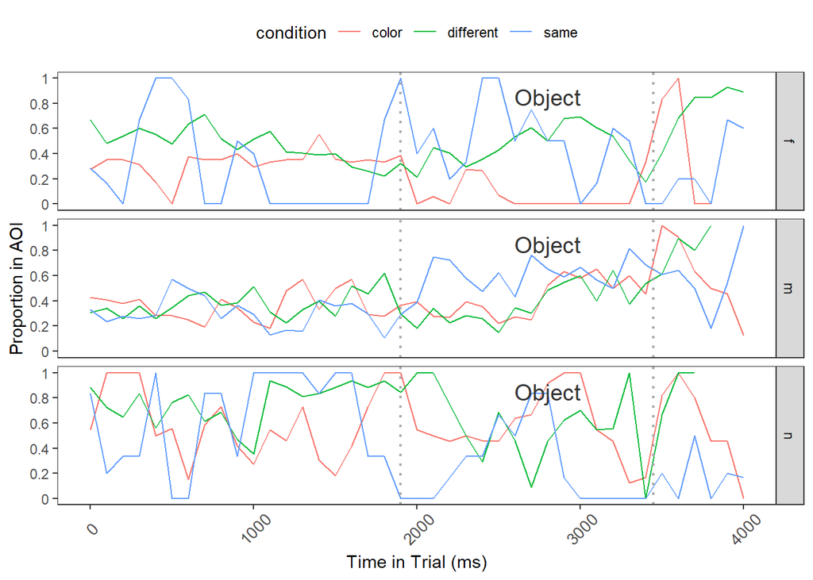

```r
ggplot(f1, aes(y = Proportion, x = TimeBin, color = condition)) +
  # lines for proportions
  geom_line() +
  # add vertical line
  geom_vline(xintercept = 1900, linetype="dotted", color = "darkgrey", size=.75) +
  # add vertical line
  geom_vline(xintercept = 3450, linetype="dotted", color = "darkgrey", size=.75) +
  # add text
  ggplot2::annotate(geom = "text", label = "Object", x = 2800, y = .85, color = "gray20", size = 5) +
  # separate panels for each target_gender
  facet_grid(target_gender ~ .) +
  # black and white theme
  theme_bw() +
  # no grid lines
  theme(panel.grid.major = element_blank(),
        panel.grid.minor = element_blank(),
        legend.position = "top",
        # define x-axis tick labels
        axis.text.x = element_text(angle = 45, vjust=0.6, size = 10)) +
  # define x-axis
  scale_x_continuous(name = "Time in Trial (ms)",
                     limits = c(0,4000),
                     breaks = seq(0,4000,1000),
                     labels = seq(0, 4000, 1000)) +
  # define y-axis
  scale_y_continuous(name = "Proportion in AOI",
                     limits = c(0, 1),
                     breaks = seq(0, 1,.2),
                     labels = seq(0, 1, .2)) +
  # save plot
  ggsave(file = here::here("images","Fig01.png"),
       height = 5,  width = 10,  dpi = 320)
```

## Lineplot with errorbars

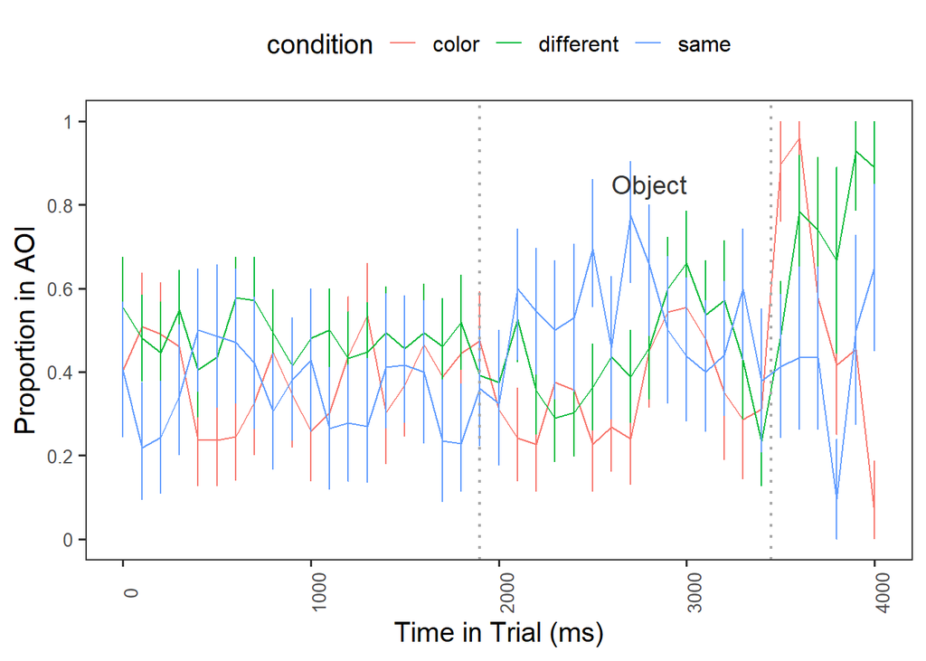

```r
# scatter plot with error bars
ggplot(dat, aes(x=TimeBin, y= AOI,  group = condition, color = condition)) +
  stat_summary(fun = mean, geom = "line", aes(group= condition, color = condition)) +
  stat_summary(fun.data = mean_cl_boot, geom = "errorbar", width = 0.2) +
  # add vertical line
  geom_vline(xintercept = 1900, linetype="dotted", color = "darkgrey", size=.75) +
  # add vertical line
  geom_vline(xintercept = 3450, linetype="dotted", color = "darkgrey", size=.75) +
  # add text
  ggplot2::annotate(geom = "text", label = "Object", x = 2800, y = .85, color = "gray20", size = 5) +
  # def. font size
  theme_bw(base_size = 15) +
  theme(axis.text.x = element_text(size=10, angle = 90),
        axis.text.y = element_text(size=10, face="plain"),
        legend.position = "top",
        panel.grid.major = element_blank(),
        panel.grid.minor = element_blank()) +
  # define x-axis
  scale_x_continuous(name = "Time in Trial (ms)",
                     limits = c(0,4000),
                     breaks = seq(0,4000,1000),
                     labels = seq(0, 4000, 1000)) +
  # define y-axis
  scale_y_continuous(name = "Proportion in AOI",
                     limits = c(0, 1),
                     breaks = seq(0, 1,.2),
                     labels = seq(0, 1, .2)) +
  # save plot
  ggsave(file = here::here("images","Fig02.png"),
       height = 5,  width = 10,  dpi = 320)
```

## Smoothed line plot

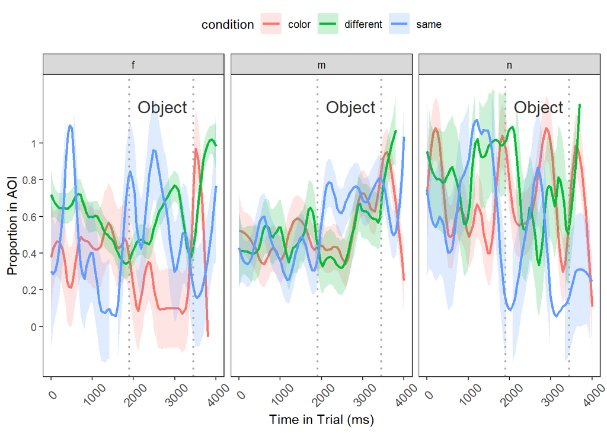

```r
ggplot(f1, aes(y = Proportion, x = TimeBin, color = condition, fill = condition)) +
  # lines for proportions
  geom_smooth(span = .2, alpha = .2) +
  # add vertical line
  geom_vline(xintercept = 1900, linetype="dotted", color = "darkgrey", size=.75) +
  # add vertical line
  geom_vline(xintercept = 3450, linetype="dotted", color = "darkgrey", size=.75) +
  # add text
  ggplot2::annotate(geom = "text", label = "Object", x = 2700, y = 1.1, color = "gray20", size = 5) +
  # separate panels for each condition
  facet_grid(~target_gender) +
  # black and white theme
  theme_bw() +
  # no grid lines
  theme(panel.grid.major = element_blank(),
        panel.grid.minor = element_blank(),
        legend.position = "top",
        # define x-axis tick labels
        axis.text.x = element_text(angle = 45, vjust=0.6, size = 10)) +
  # define x-axis
  scale_x_continuous(name = "Time in Trial (ms)",
                     limits = c(0,4000),
                     breaks = seq(0,4000,1000),
                     labels = seq(0, 4000, 1000)) +
  # define y-axis
  scale_y_continuous(name = "Proportion in AOI",
                     limits = c(-.3, 1.2),
                     breaks = seq(-.1, 1,.2),
                     labels = seq(0, 1, .2)) +
  # save plot
  ggsave(file = here::here("images","Fig03.png"),
       height = 5,  width = 10,  dpi = 320)
```

# Statz

We use a mixed-effects binomial logistic regression, to check if the conditions affect the proportion of AOI gazes during a period of interest (after the stimulus was shown).

We go over this without much explanation. However, if you want to know more about how mixed-effects model work, what to consider, and how to interpret them, Gries (2021), Winter (2019), or Field, Miles, and Field (2012) are highly recommendable resources! You can also find additional information [here](https://slcladal.github.io/mmws.html) or [here](https://slcladal.github.io/regression.html#2_Mixed-Effects_Regression).

```r
# set options
options(contrasts  = c("contr.treatment", "contr.poly"))
#options(contrasts  = c("contr.helmert", "contr.poly"))
#options(contrasts  = c("contr.sum", "contr.poly"))
```

```r
statzdat <- dat %>%
  dplyr::filter(time_elapsed > 1900 &
                  time_elapsed < 3450)
```

Generate base-line model.

```r
# generate model
m0 <- glmer(AOI ~ (1  | trial) + (1 | target_item),
                  family = binomial,
                  data = statzdat,
                  control=glmerControl(optimizer="bobyqa"))
```

Generate final model.

```r
# generate model
m1 <- update(m0, .~.+ condition * target_gender)
```

Summarize the final model.

```r
# generate model
summary(m1)
```

```
## Generalized linear mixed model fit by maximum likelihood (Laplace
##   Approximation) [glmerMod]
##  Family: binomial  ( logit )
## Formula: AOI ~ (1 | trial) + (1 | target_item) + condition + target_gender +
##     condition:target_gender
##    Data: statzdat
## Control: glmerControl(optimizer = "bobyqa")
##
##      AIC      BIC   logLik deviance df.resid
##   2620.7   2684.1  -1299.3   2598.7     2342
##
## Scaled residuals:
##        Min         1Q     Median         3Q        Max
## -1.9018983 -0.5924559 -0.2865166  0.7971668  6.6556680
##
## Random effects:
##  Groups      Name        Variance  Std.Dev.
##  trial       (Intercept) 0.5226661 0.7229565
##  target_item (Intercept) 0.4876538 0.6983221
## Number of obs: 2353, groups:  trial, 14; target_item, 14
##
## Fixed effects:
##                                     Estimate Std. Error  z value   Pr(>|z|)
## (Intercept)                       -2.7559441  0.7765836 -3.54881 0.00038698 ***
## conditiondifferent                 2.3637090  1.0579677  2.23420 0.02547007 *
## conditionsame                      2.8273760  1.2887835  2.19383 0.02824741 *
## target_genderm                     2.4554414  1.0600904  2.31626 0.02054426 *
## target_gendern                     3.2119081  1.2793522  2.51057 0.01205351 *
## conditiondifferent:target_genderm -3.0855554  1.4717650 -2.09650 0.03603786 *
## conditionsame:target_genderm      -2.1499007  1.6431608 -1.30839 0.19073992
## conditiondifferent:target_gendern -2.4415407  1.7851907 -1.36766 0.17141733
## conditionsame:target_gendern      -4.3956687  1.9392252 -2.26671 0.02340771 *
## ---
## Signif. codes:  0 '***' 0.001 '**' 0.01 '*' 0.05 '.' 0.1 ' ' 1
##
## Correlation of Fixed Effects:
##                        (Intr) cndtnd cndtns trgt_gndrm trgt_gndrn
## cndtndffrnt            -0.734
## conditionsm            -0.603  0.442
## targt_gndrm            -0.731  0.536  0.441
```

[output cut: 8 more lines]

```
## targt_gndrm
## targt_gndrn
## cndtndffrnt:trgt_gndrm
## cndtnsm:trgt_gndrm      0.465
## cndtndffrnt:trgt_gndrn  0.426                  0.205
## cndtnsm:trgt_gndrn      0.211                  0.521
##                        cndtndffrnt:trgt_gndrn
## cndtndffrnt
## conditionsm
## targt_gndrm
## targt_gndrn
## cndtndffrnt:trgt_gndrm
## cndtnsm:trgt_gndrm
## cndtndffrnt:trgt_gndrn
## cndtnsm:trgt_gndrn      0.473
```

Run Post-hoc tests

```r
summary(glht(m1, mcp(condition="Tukey")))
```

```
##
##   Simultaneous Tests for General Linear Hypotheses
##
## Multiple Comparisons of Means: Tukey Contrasts
##
##
## Fit: glmer(formula = AOI ~ (1 | trial) + (1 | target_item) + condition +
##     target_gender + condition:target_gender, data = statzdat,
##     family = binomial, control = glmerControl(optimizer = "bobyqa"))
##
## Linear Hypotheses:
##                        Estimate Std. Error z value Pr(>|z|)
## different - color == 0 2.363709   1.057968 2.23420 0.064945 .
## same - color == 0      2.827376   1.288784 2.19383 0.071678 .
## same - different == 0  0.463667   1.254827 0.36951 0.927100
## ---
## Signif. codes:  0 '***' 0.001 '**' 0.01 '*' 0.05 '.' 0.1 ' ' 1
## (Adjusted p values reported -- single-step method)
```

We now tabulate the results of the final model.

```r
# generate summary table
sjPlot::tab_model(m0, m1)
```

|  | AOI |  |  | AOI |  |  |
| --- | --- | --- | --- | --- | --- | --- |
| Predictors | Odds Ratios | CI | p | Odds Ratios | CI | p |
| (Intercept) | 0.56 | 0.26 – 1.18 | 0.125 | 0.06 | 0.01 – 0.29 | **<0.001** |
| condition [different] |  |  |  | 10.63 | 1.34 – 84.55 | **0.025** |
| condition [same] |  |  |  | 16.90 | 1.35 – 211.31 | **0.028** |
| target_gender [m] |  |  |  | 11.65 | 1.46 – 93.05 | **0.021** |
| target_gender [n] |  |  |  | 24.83 | 2.02 – 304.72 | **0.012** |
| condition [different] * target_gender [m] |  |  |  | 0.05 | 0.00 – 0.82 | **0.036** |
| condition [same] * target_gender [m] |  |  |  | 0.12 | 0.00 – 2.92 | 0.191 |
| condition [different] * target_gender [n] |  |  |  | 0.09 | 0.00 – 2.88 | 0.171 |
| condition [same] * target_gender [n] |  |  |  | 0.01 | 0.00 – 0.55 | **0.023** |
| Random Effects |  |  |  |  |  |  |
| σ<sup>2</sup> | 3.29 |  |  | 3.29 |  |  |
| τ<sub>00</sub> | 1.01 <sub>trial</sub> |  |  | 0.52 <sub>trial</sub> |  |  |
|  | 0.98 <sub>target_item</sub> |  |  | 0.49 <sub>target_item</sub> |  |  |
| ICC | 0.38 |  |  | 0.23 |  |  |
| N | 14 <sub>trial</sub> |  |  | 14 <sub>trial</sub> |  |  |
|  | 14 <sub>target_item</sub> |  |  | 14 <sub>target_item</sub> |  |  |
| Observations | 2353 |  |  | 2353 |  |  |
| Marginal R<sup>2</sup> / Conditional R<sup>2</sup> | 0.000 / 0.377 |  |  | 0.158 / 0.356 |  |  |

And we visualize the fixed effects.

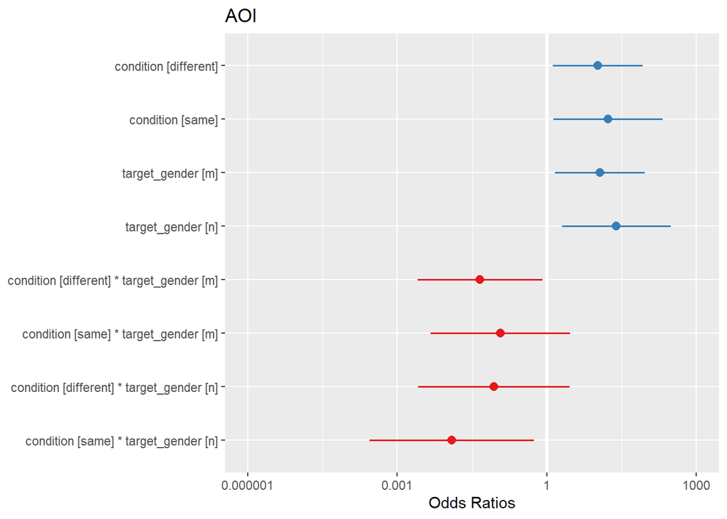

```r
sjPlot::plot_model(m1)
```

# eyetrackeR

Once the data is in in a proper format, we can also use the `eyetrackeR` package for our analysis. The advantage of using the `eyetrackeR` package is that is has many in-built functions that make the analysis of eye-tracking data a lot easier. Also, there are [very helpful and detailed tutorials](http://www.eyetracking-r.com/) on how to perform analyses and visualize eye-tracking data using `eyetrackeR`.

Before we can use the `eyetrackeR` package, however, we need to create certain columns in our data that the `eyetrackeR` package expects.

In our case, we need to create a

- column specifying if a gaze was in the AOI (which we will call `OnTarget`)
- column specifying if a gaze was not in the AOI (which we will call `OffTarget`).
- `trackloss_column` (which we will call `Trackloss`). This column contains information about data point that we want to remove during the analysis. In our case, we will code data points that have negative x- and y-coordinates as well as data points that occurred after 4200ms as TRUE (meaning that we consider them cases of trackloss).

```r
dat <- dat %>%
  dplyr::mutate(TrackLoss = dplyr::case_when(x_pred < 0 ~ TRUE,
                                             y_pred < 0 ~ TRUE,
                                             time_elapsed > 4200 ~ TRUE,
                                             TRUE ~ FALSE)) %>%
  dplyr::mutate(OnTarget = dplyr::case_when(AOI == 1 ~ 1,
                                            TRUE ~ 0),
                OffTarget = dplyr::case_when(AOI == 1 ~ 0,
                                            TRUE ~ 1))
```

Now that we have generated the required columns in our data, we can generate an `eyetrackingr_data` and specify the columns that the `eyetraceR` package wants us to specify.

```r
data <- make_eyetrackingr_data(dat,
                       participant_column = "participant_id",
                       trial_column = "trial",
                       time_column = "time_elapsed",
                       trackloss_column = "TrackLoss",
                       aoi_columns = c('OnTarget','OffTarget'),
                       treat_non_aoi_looks_as_missing = TRUE
)
# inspect data
head(data)
```

```
## # A tibble: 6 x 29
##   participant_id time_elapsed type  x_pred y_pred face_conf zone_name trial
##   <fct>                 <dbl> <chr>  <dbl>  <dbl>     <dbl> <chr>     <fct>
## 1 3699461                 0   pred~    753    467     0.814 <NA>      10
## 2 3699461                17.9 pred~    771    498     0.814 <NA>      10
## 3 3699461                33.9 pred~    843    454     0.814 <NA>      10
## 4 3699461                49.4 pred~    654    536     0.814 <NA>      10
## 5 3699461                65.3 pred~    619    462     0.814 <NA>      10
## 6 3699461                85.0 pred~    633    438     0.814 <NA>      10
## # ... with 21 more variables: id <int>, left_bottomedge <dbl>,
## #   left_leftedge <dbl>, left_rightedge <dbl>, left_topedge <dbl>,
## #   right_bottomedge <dbl>, right_leftedge <dbl>, right_rightedge <dbl>,
## #   right_topedge <dbl>, condition <chr>, target_gender <chr>,
## #   target_position <chr>, `Zone Type` <chr>, Response <chr>, Correct <fct>,
## #   target_item <chr>, AOI <dbl>, TimeBin <dbl>, TrackLoss <lgl>,
## #   OnTarget <lgl>, OffTarget <lgl>
```

We can also tabulate the number of `*on target* gazes that remain in the data using the`table` function.

```r
table(data$OnTarget)
```

```
##
## FALSE  TRUE
##  3277  2644
```

In a next step, we specify the window that we want to inspect (in our case, we want to check the window starting at 1900 ms and ending at 3450 ms).

```r
# subset to response window post word-onset
response_window <- subset_by_window(data,
                                    window_start_time = 1900,
                                    window_end_time = 3450,
                                    rezero = FALSE)
```

We now check to see if we need to remove data points.

```r
# analyze amount of trackloss by subjects and trials
(trackloss <- trackloss_analysis(data = response_window))
```

```
## # A tibble: 30 x 6
##    participant_id trial Samples TracklossSamples TracklossForTri~
##    <fct>          <fct>   <dbl>            <dbl>            <dbl>
##  1 3699461        10         82                0                0
##  2 3699461        11         76                0                0
##  3 3699461        16         90                0                0
##  4 3699461        17         93                0                0
##  5 3699461        3          88                0                0
##  6 3699461        4          91                0                0
##  7 3699461        5          92                0                0
##  8 3699461        7          84                0                0
##  9 3699461        8          85                0                0
## 10 3699461        9          62                0                0
## # ... with 20 more rows, and 1 more variable: TracklossForParticipant <dbl>
```

Remove trackloss (trial_prop_thresh greater than or equal to .25).

```r
# remove trials with > 25% of trackloss
response_window_clean <- clean_by_trackloss(data = response_window,
                                            trial_prop_thresh = .25)
```

Extract response data.

```r
# aggregate across trials within subjects in time analysis
response <- make_time_sequence_data(response_window_clean,
                                    time_bin_size = 50,
                                    predictor_columns = c("condition", "Correct"),
                                    aois = c("OnTarget", "OffTarget")
                            )
```

Visualize response data.

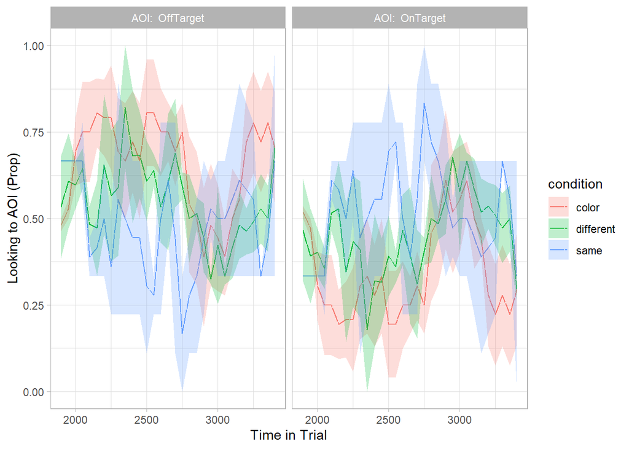

```r
# visualize time results
plot(response,
     predictor_column = "condition") +
  theme_light() +
  coord_cartesian(ylim = c(0,1))
```

# Citation & Session Info

Schweinberger, Martin. 2021. *Processing and Analyzing Eye-Tracking Data in R. Workshop at UIT AcqVA Aurora*. Tromsø: The Artic University of Norway. url: https://slcladal.github.io/eyews.html (Version 2021.05.05).

```
@manual{schweinberger2021eyews,
  author = {Schweinberger, Martin},
  title = {Processing and Analyzing Eye-Tracking Data in R},
  note = {https://slcladal.github.io/eyews.html},
  year = {2021},
  organization = "Arctic University of Norway, AcqVA Aurora Center},
  address = {Tromsø},
  edition = {2021.05.05}
}
```

Back to top

# References

Field, Andy, Jeremy Miles, and Zoe Field. 2012. *Discovering Statistics Using R*. Sage.

Gries, Stefan Th. 2021. *Statistics for Linguistics Using R: A Practical Introduction*. Berlin & New York: Mouton de Gruyter.

Winter, Bodo. 2019. *Statistics for Linguists: An Introduction Using R*. Routledge.